# Part II: Airbnb + Real Estate Project

*Source file* ⇒ Airbnb_+_Real_Estate.Rmd

## Analysis of Airbnb and Real Estate data

This is the second part of the project, here is the first part In the “With_Real_Estate” document, I showed how I obtained the data from a website of Real Estate website. Here I start from downloading the datasets from [Airbnb Data Collection](http://tomslee.net/airbnb-data-collection-get-the-data).

### Obtain the Airbnb Data

I chose Florence, Turin and Venice data from June 2017, and created a combined the three datasets into a compact one “AirbnbItaly”.

```r
Florence06 <- read.csv(("florence_1366_2017-06-22.csv")) %>%
  mutate(city = "F") #%>%
  #This next line might be useful for future projects, not for this one in particular
  #select(room_id,room_type,city,reviews,overall_satisfaction,accommodates,bedrooms,price, neighborhood, latitude,longitude)
Turin06 <- read.csv("turin_1407_2017-06-28.csv")%>%
  mutate(city = "T")
Venice06 <- read.csv("venice_1361_2017-06-22.csv") %>%
  mutate(city = "V")
AirbnbItaly <-
  rbind(Venice06, Florence06, Turin06)
```

Then I grouped by the city name and neighborhood and summarized the dataset using the median price. The median is useful for the comparisons. I also renamed the variable “neighborhood” into “Areas” in order to not get confused with the variable in the scraped dataset.

```r
FinalAirbnb <- AirbnbItaly %>%
  group_by(city, neighborhood) %>%
  summarise(medianAirbnb = median(price)) %>%
  arrange(desc(medianAirbnb)) %>%
  rename('Areas' = 'neighborhood')
knitr::kable(head(FinalAirbnb,3))
```

| city | Areas | medianAirbnb |
| --- | --- | --- |
| V | VENEZIA - MURANO - BURANO (VENEZIA INSULARE) | 138 |
| V | LIDO - PELLESTRINA (VENEZIA LITORALE) | 115 |
| F | Centro Storico | 97 |

### Load Real Estate dataset

First, I loaded the dataset that I had previously exported in the first part of the project I also wrote key.cvs in order to match the neighborhoods from the scraped dataset with the Areas in the Airbnb dataset. The matching was done manually through research conducted on Wikipedia.

```r
Estate <- read.csv("table.csv") %>%
  select(neigh, price)
key <- read.csv("key.csv")
```

```r
Joined <- key %>%
  full_join(Estate, by = "neigh") %>%
  select(city, Areas, neigh, price) %>%
  rename('neighborhood' = 'neigh') %>%
  rename('estateprice' = 'price') %>%
  na.omit()
knitr::kable(head(Joined, 3))
```

| city | Areas | neighborhood | estateprice |
| --- | --- | --- | --- |
| F | Campo di Marte | Firenze - 16 - Le Cure | 515 |
| F | Campo di Marte | Firenze - 16 - Le Cure | 420 |
| F | Campo di Marte | Firenze - 16 - Le Cure | 170 |

I calculated the median for the real estate data too.

```r
FinalEstate <- Joined %>%
  group_by(city, Areas) %>%
  summarise(medianEstate_inthousands = median(estateprice)) %>%
  arrange(desc(medianEstate_inthousands)) %>%
  select(medianEstate_inthousands, Areas, city)
knitr::kable(head(FinalEstate, 3))
```

| medianEstate_inthousands | Areas | city |
| --- | --- | --- |
| 362.5 | LIDO - PELLESTRINA (VENEZIA LITORALE) | V |
| 360.0 | Isolotto- Legnaia | F |
| 355.0 | Centro - Crocetta | T |

### Some distribution plots

To give an idea of how the both datasets are distributed, I used ggplot from DataComputing package. We can see that most of the Airbnb rentals tend to cheapest in Turin and most expensive in Venice.

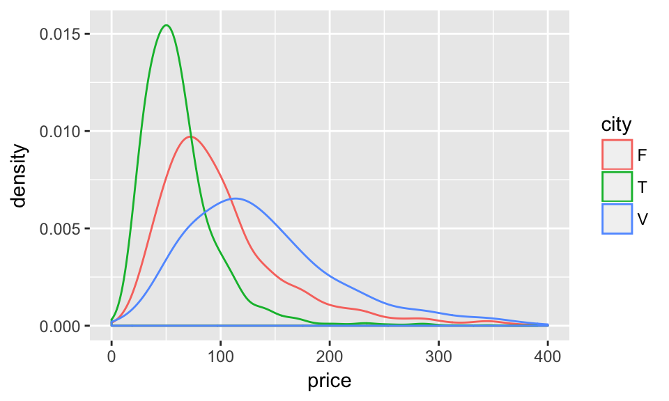

```r
AirbnbItaly %>%
  ggplot(aes(x=price, group=city, color=city)) +
  geom_density(adjust=2) +
  xlim(0, 400)
```

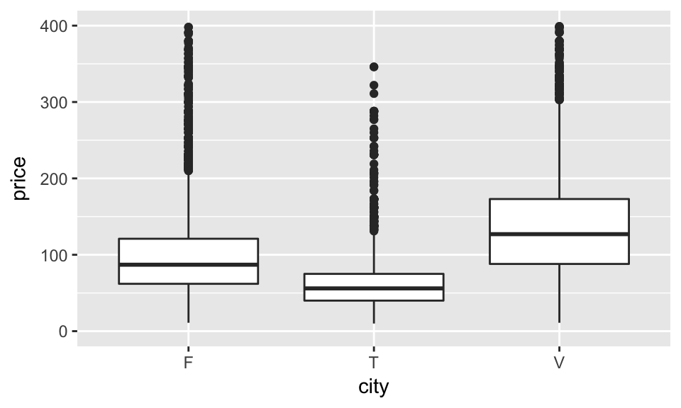

```r
AirbnbItaly %>%
  ggplot(aes(x=city, y=price)) +
  geom_boxplot() +
  ylim(0,400)
```

The same plots are shown for the Real Estate data and the results are slighly different: while Turin has on average the cheapest house prices, Venice does not have as the most expensive houses. Florence has on average the most expensive houses. This is an interesting point to consider for our final analysis.

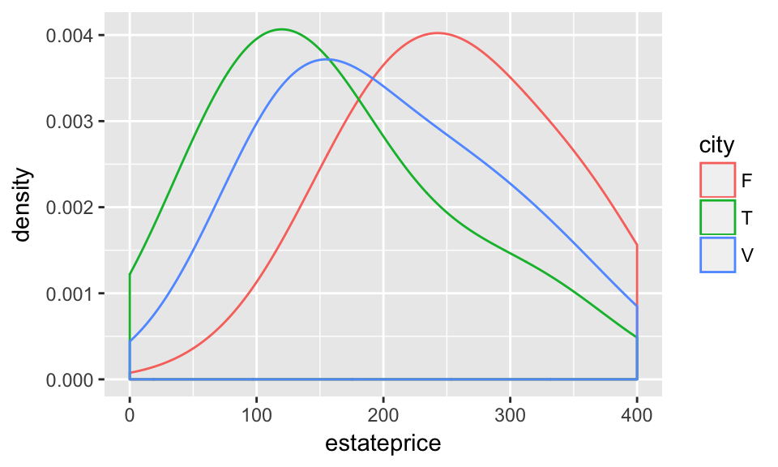

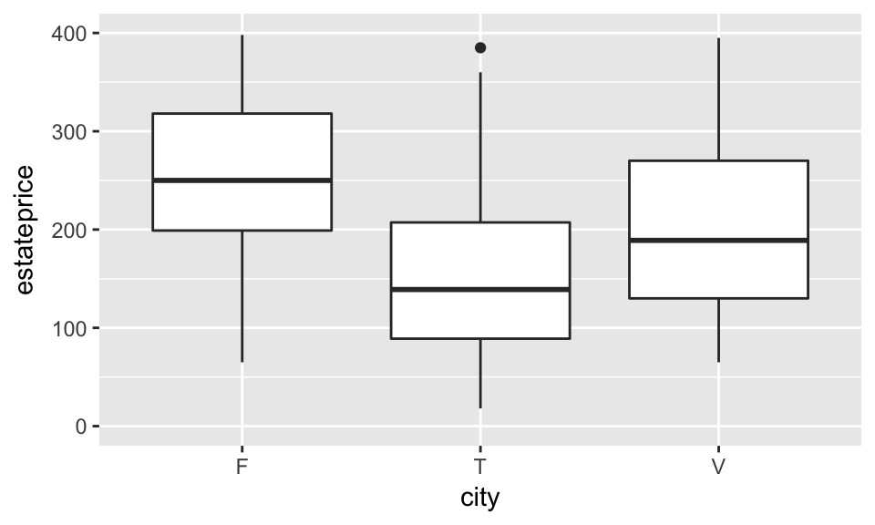

### Combine the scraped with the Airbnb dataset

Now, on our last step: combining the two scraped dataset (which was previously matched through they key) with the Airbnb dataset.

```r
Airbnb_Estate <- FinalAirbnb %>%
  full_join(FinalEstate, by = "Areas") %>%
  select(Areas, city.x, medianAirbnb, medianEstate_inthousands) %>%
  arrange(desc(medianEstate_inthousands))
knitr::kable(head(Airbnb_Estate,3))
```

| Areas | city.x | medianAirbnb | medianEstate_inthousands |
| --- | --- | --- | --- |
| LIDO - PELLESTRINA (VENEZIA LITORALE) | V | 115 | 362.5 |
| Isolotto- Legnaia | F | 69 | 360.0 |
| Centro - Crocetta | T | 68 | 355.0 |

### Where should I buy a house?

Everything done so far was just “getting the data”. Now we can answer our original question:“Where should I buy a house to be more profitable by renting it on Airbnb?” There are some assumptions to be made:

- Every price listing on Airbnb stay constant throughout the years
- Every listing on Airbnb is rented out every day

The goal is to observe if there is a certain neighborhood, and if possible, even a certain city in which this ratio will be the lowest.

```r
Airbnb_Estate <- Airbnb_Estate %>%
  mutate(ratio = (medianEstate_inthousands * 1000 / (medianAirbnb * 365)))  %>%
  arrange(ratio)
knitr::kable(head(Airbnb_Estate))
```

| Areas | city.x | medianAirbnb | medianEstate_inthousands | ratio |
| --- | --- | --- | --- | --- |
| CHIRIGNAGO - ZELARINO ( MESTRE OVEST) | V | 64 | 125.0 | 5.351027 |
| Barriera di Milano - Regio Parco - Barca - Bertolla - Falchera - Rebaudengo - Villaretto | T | 40 | 79.0 | 5.410959 |
| MARGHERA | V | 69 | 140.0 | 5.558864 |
| VENEZIA - MURANO - BURANO (VENEZIA INSULARE) | V | 138 | 307.5 | 6.104824 |
| MESTRE - CARPENEDO (MESTRE CENTRO) | V | 69 | 155.0 | 6.154457 |
| FAVARO VENETO | V | 69 | 160.0 | 6.352988 |

Seems Venice is overall the most profitable city as 5 out of the top 6 neighborhoods are from Venice! (You will be able to gain back the amount spent on buying the house in 5-6years only!)

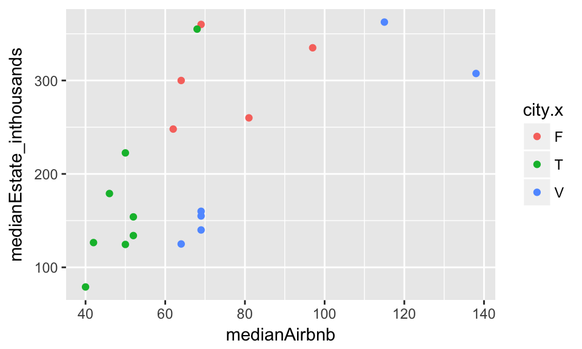

```r
library(ggplot2)
ggplot(data=Airbnb_Estate,aes(x=medianAirbnb,y=medianEstate_inthousands))+geom_point()+aes(colour=city.x)
```

So to answer our final question: If we want to buy one house from one specific neighborhood, we should choose CHIRIGNAGO - ZELARINO ( MESTRE OVEST) from Venice If we want to choose one city, Venice is the choice to go for!

## Good luck with finals guys!